# Optimal Treatment Analysis

## Outcome Variable

**Outcome Variable:** ever_stunted

## Predictor Variables

**Intervention Variable:** mbmi

**Adjustment Set:**

- arm
- W_mage
- meducyrs
- feducyrs
- single
- brthmon
- delta_W_mage
- delta_meducyrs
- delta_feducyrs
- delta_single
- delta_brthmon

## Stratifying Variables

The analysis was stratified on these variable(s):

- agecat
- studyid
- country

## Data Summary

| agecat | studyid | country | mbmi | ever_stunted | n_cell | n |
| --- | --- | --- | --- | --- | --- | --- |
| 0-24 months | ki0047075b-MAL-ED | BANGLADESH | Normal weight | 0 | 90 | 254 |
| 0-24 months | ki0047075b-MAL-ED | BANGLADESH | Normal weight | 1 | 132 | 254 |
| 0-24 months | ki0047075b-MAL-ED | BANGLADESH | Underweight | 0 | 9 | 254 |
| 0-24 months | ki0047075b-MAL-ED | BANGLADESH | Underweight | 1 | 23 | 254 |
| 0-24 months | ki0047075b-MAL-ED | BRAZIL | Normal weight | 0 | 165 | 221 |
| 0-24 months | ki0047075b-MAL-ED | BRAZIL | Normal weight | 1 | 46 | 221 |
| 0-24 months | ki0047075b-MAL-ED | BRAZIL | Underweight | 0 | 6 | 221 |
| 0-24 months | ki0047075b-MAL-ED | BRAZIL | Underweight | 1 | 4 | 221 |
| 0-24 months | ki0047075b-MAL-ED | INDIA | Normal weight | 0 | 75 | 242 |
| 0-24 months | ki0047075b-MAL-ED | INDIA | Normal weight | 1 | 118 | 242 |
| 0-24 months | ki0047075b-MAL-ED | INDIA | Underweight | 0 | 20 | 242 |
| 0-24 months | ki0047075b-MAL-ED | INDIA | Underweight | 1 | 29 | 242 |
| 0-24 months | ki0047075b-MAL-ED | NEPAL | Normal weight | 0 | 156 | 238 |
| 0-24 months | ki0047075b-MAL-ED | NEPAL | Normal weight | 1 | 82 | 238 |
| 0-24 months | ki0047075b-MAL-ED | NEPAL | Underweight | 0 | 0 | 238 |
| 0-24 months | ki0047075b-MAL-ED | NEPAL | Underweight | 1 | 0 | 238 |
| 0-24 months | ki0047075b-MAL-ED | PERU | Normal weight | 0 | 102 | 290 |
| 0-24 months | ki0047075b-MAL-ED | PERU | Normal weight | 1 | 183 | 290 |
| 0-24 months | ki0047075b-MAL-ED | PERU | Underweight | 0 | 2 | 290 |
| 0-24 months | ki0047075b-MAL-ED | PERU | Underweight | 1 | 3 | 290 |
| 0-24 months | ki0047075b-MAL-ED | SOUTH AFRICA | Normal weight | 0 | 110 | 270 |
| 0-24 months | ki0047075b-MAL-ED | SOUTH AFRICA | Normal weight | 1 | 152 | 270 |
| 0-24 months | ki0047075b-MAL-ED | SOUTH AFRICA | Underweight | 0 | 1 | 270 |
| 0-24 months | ki0047075b-MAL-ED | SOUTH AFRICA | Underweight | 1 | 7 | 270 |
| 0-24 months | ki0047075b-MAL-ED | TANZANIA, UNITED REPUBLIC OF | Normal weight | 0 | 33 | 256 |
| 0-24 months | ki0047075b-MAL-ED | TANZANIA, UNITED REPUBLIC OF | Normal weight | 1 | 209 | 256 |
| 0-24 months | ki0047075b-MAL-ED | TANZANIA, UNITED REPUBLIC OF | Underweight | 0 | 3 | 256 |
| 0-24 months | ki0047075b-MAL-ED | TANZANIA, UNITED REPUBLIC OF | Underweight | 1 | 11 | 256 |
| 0-24 months | ki1000304b-SAS-CompFeed | INDIA | Normal weight | 0 | 360 | 1406 |
| 0-24 months | ki1000304b-SAS-CompFeed | INDIA | Normal weight | 1 | 691 | 1406 |

[output cut: 158 more lines]

The following strata were considered:

- agecat: 0-24 months, studyid: ki0047075b-MAL-ED, country: BANGLADESH
- agecat: 0-24 months, studyid: ki0047075b-MAL-ED, country: BRAZIL
- agecat: 0-24 months, studyid: ki0047075b-MAL-ED, country: INDIA
- agecat: 0-24 months, studyid: ki0047075b-MAL-ED, country: NEPAL
- agecat: 0-24 months, studyid: ki0047075b-MAL-ED, country: PERU
- agecat: 0-24 months, studyid: ki0047075b-MAL-ED, country: SOUTH AFRICA
- agecat: 0-24 months, studyid: ki0047075b-MAL-ED, country: TANZANIA, UNITED REPUBLIC OF
- agecat: 0-24 months, studyid: ki1000304b-SAS-CompFeed, country: INDIA
- agecat: 0-24 months, studyid: ki1017093-NIH-Birth, country: BANGLADESH
- agecat: 0-24 months, studyid: ki1017093b-PROVIDE, country: BANGLADESH
- agecat: 0-24 months, studyid: ki1017093c-NIH-Crypto, country: BANGLADESH
- agecat: 0-24 months, studyid: ki1066203-TanzaniaChild2, country: TANZANIA, UNITED REPUBLIC OF
- agecat: 0-24 months, studyid: ki1112895-iLiNS-Zinc, country: BURKINA FASO
- agecat: 0-24 months, studyid: ki1119695-PROBIT, country: BELARUS
- agecat: 0-24 months, studyid: ki1126311-ZVITAMBO, country: ZIMBABWE
- agecat: 0-24 months, studyid: ki1148112-LCNI-5, country: MALAWI
- agecat: 0-6 months, studyid: ki0047075b-MAL-ED, country: BANGLADESH
- agecat: 0-6 months, studyid: ki0047075b-MAL-ED, country: BRAZIL
- agecat: 0-6 months, studyid: ki0047075b-MAL-ED, country: INDIA
- agecat: 0-6 months, studyid: ki0047075b-MAL-ED, country: NEPAL
- agecat: 0-6 months, studyid: ki0047075b-MAL-ED, country: PERU
- agecat: 0-6 months, studyid: ki0047075b-MAL-ED, country: SOUTH AFRICA
- agecat: 0-6 months, studyid: ki0047075b-MAL-ED, country: TANZANIA, UNITED REPUBLIC OF
- agecat: 0-6 months, studyid: ki1000304b-SAS-CompFeed, country: INDIA
- agecat: 0-6 months, studyid: ki1017093-NIH-Birth, country: BANGLADESH
- agecat: 0-6 months, studyid: ki1017093b-PROVIDE, country: BANGLADESH
- agecat: 0-6 months, studyid: ki1017093c-NIH-Crypto, country: BANGLADESH
- agecat: 0-6 months, studyid: ki1066203-TanzaniaChild2, country: TANZANIA, UNITED REPUBLIC OF
- agecat: 0-6 months, studyid: ki1119695-PROBIT, country: BELARUS
- agecat: 0-6 months, studyid: ki1126311-ZVITAMBO, country: ZIMBABWE
- agecat: 0-6 months, studyid: ki1148112-LCNI-5, country: MALAWI
- agecat: 6-24 months, studyid: ki0047075b-MAL-ED, country: BANGLADESH
- agecat: 6-24 months, studyid: ki0047075b-MAL-ED, country: BRAZIL
- agecat: 6-24 months, studyid: ki0047075b-MAL-ED, country: INDIA
- agecat: 6-24 months, studyid: ki0047075b-MAL-ED, country: NEPAL
- agecat: 6-24 months, studyid: ki0047075b-MAL-ED, country: PERU
- agecat: 6-24 months, studyid: ki0047075b-MAL-ED, country: SOUTH AFRICA
- agecat: 6-24 months, studyid: ki0047075b-MAL-ED, country: TANZANIA, UNITED REPUBLIC OF
- agecat: 6-24 months, studyid: ki1000304b-SAS-CompFeed, country: INDIA
- agecat: 6-24 months, studyid: ki1017093-NIH-Birth, country: BANGLADESH
- agecat: 6-24 months, studyid: ki1017093b-PROVIDE, country: BANGLADESH
- agecat: 6-24 months, studyid: ki1017093c-NIH-Crypto, country: BANGLADESH
- agecat: 6-24 months, studyid: ki1066203-TanzaniaChild2, country: TANZANIA, UNITED REPUBLIC OF
- agecat: 6-24 months, studyid: ki1112895-iLiNS-Zinc, country: BURKINA FASO
- agecat: 6-24 months, studyid: ki1119695-PROBIT, country: BELARUS
- agecat: 6-24 months, studyid: ki1126311-ZVITAMBO, country: ZIMBABWE
- agecat: 6-24 months, studyid: ki1148112-LCNI-5, country: MALAWI

### Dropped Strata

Some strata were dropped due to rare outcomes:

- agecat: 0-24 months, studyid: ki0047075b-MAL-ED, country: BRAZIL
- agecat: 0-24 months, studyid: ki0047075b-MAL-ED, country: NEPAL
- agecat: 0-24 months, studyid: ki0047075b-MAL-ED, country: PERU
- agecat: 0-24 months, studyid: ki0047075b-MAL-ED, country: SOUTH AFRICA
- agecat: 0-24 months, studyid: ki0047075b-MAL-ED, country: TANZANIA, UNITED REPUBLIC OF
- agecat: 0-6 months, studyid: ki0047075b-MAL-ED, country: BRAZIL
- agecat: 0-6 months, studyid: ki0047075b-MAL-ED, country: NEPAL
- agecat: 0-6 months, studyid: ki0047075b-MAL-ED, country: PERU
- agecat: 0-6 months, studyid: ki0047075b-MAL-ED, country: SOUTH AFRICA
- agecat: 6-24 months, studyid: ki0047075b-MAL-ED, country: BRAZIL
- agecat: 6-24 months, studyid: ki0047075b-MAL-ED, country: NEPAL
- agecat: 6-24 months, studyid: ki0047075b-MAL-ED, country: PERU
- agecat: 6-24 months, studyid: ki0047075b-MAL-ED, country: SOUTH AFRICA
- agecat: 6-24 months, studyid: ki0047075b-MAL-ED, country: TANZANIA, UNITED REPUBLIC OF

## Methods Detail

We’re interested in the causal parameters $E[Y_a]$ for all values of $a \in \mathcal{A}$. These parameters represent the mean outcome if, possibly contrary to fact, we intervened to set all units to have $A=a$. Under the randomization and positivity assumptions, these are identified by the statistical parameters $\psi_a=E_W[E_{Y|A,W}(Y|A=a,W)]$. In addition, we’re interested in the mean of $Y$, $E[Y]$ under no intervention (the observed mean). We will estimate these parameters by using SuperLearner to fit the relevant likelihood factors – $E_{Y|A,W}(Y|A=a,W)$ and $p(A=a|W)$, and then updating our likelihood fit using a joint TMLE.

For unadjusted analyses ($W=\{\}$), initial likelihoods were estimated using Lrnr_glm to estimate the simple $E(Y|A)$ and Lrnr_mean to estimate $p(A)$. For adjusted analyses, a small library containing Lrnr_glmnet, Lrnr_xgboost, and Lrnr_mean was used.

Having estimated these parameters, we will then use the delta method to estimate relative risks and attributable risks relative to a prespecified baseline level of $A$.

# Results Detail

## Results Plots

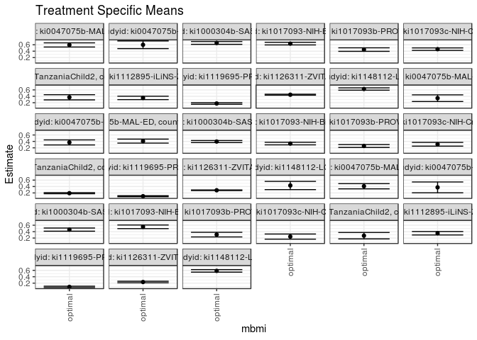

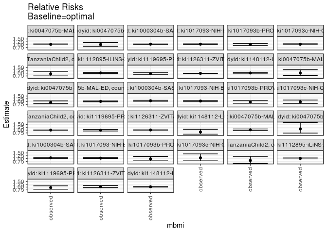

## Results Table

### Parameter: TSM

| agecat | studyid | country | intervention_level | baseline_level | estimate | ci_lower | ci_upper |
| --- | --- | --- | --- | --- | --- | --- | --- |
| 0-24 months | ki0047075b-MAL-ED | BANGLADESH | optimal | NA | 0.5950477 | 0.5302441 | 0.6598514 |
| 0-24 months | ki0047075b-MAL-ED | INDIA | optimal | NA | 0.5999629 | 0.4803777 | 0.7195480 |
| 0-24 months | ki1000304b-SAS-CompFeed | INDIA | optimal | NA | 0.6569104 | 0.6129884 | 0.7008323 |
| 0-24 months | ki1017093-NIH-Birth | BANGLADESH | optimal | NA | 0.6361595 | 0.5948702 | 0.6774488 |
| 0-24 months | ki1017093b-PROVIDE | BANGLADESH | optimal | NA | 0.4499380 | 0.3949977 | 0.5048783 |
| 0-24 months | ki1017093c-NIH-Crypto | BANGLADESH | optimal | NA | 0.4627294 | 0.4238742 | 0.5015845 |
| 0-24 months | ki1066203-TanzaniaChild2 | TANZANIA, UNITED REPUBLIC OF | optimal | NA | 0.3689881 | 0.2882831 | 0.4496930 |
| 0-24 months | ki1112895-iLiNS-Zinc | BURKINA FASO | optimal | NA | 0.3497445 | 0.2966864 | 0.4028026 |
| 0-24 months | ki1119695-PROBIT | BELARUS | optimal | NA | 0.1758314 | 0.1514302 | 0.2002326 |
| 0-24 months | ki1126311-ZVITAMBO | ZIMBABWE | optimal | NA | 0.4492405 | 0.4350151 | 0.4634659 |
| 0-24 months | ki1148112-LCNI-5 | MALAWI | optimal | NA | 0.6273750 | 0.5912815 | 0.6634685 |
| 0-6 months | ki0047075b-MAL-ED | BANGLADESH | optimal | NA | 0.3415643 | 0.2377165 | 0.4454121 |
| 0-6 months | ki0047075b-MAL-ED | INDIA | optimal | NA | 0.3681833 | 0.2893605 | 0.4470060 |
| 0-6 months | ki0047075b-MAL-ED | TANZANIA, UNITED REPUBLIC OF | optimal | NA | 0.4094143 | 0.3472997 | 0.4715290 |
| 0-6 months | ki1000304b-SAS-CompFeed | INDIA | optimal | NA | 0.3957827 | 0.3631045 | 0.4284609 |
| 0-6 months | ki1017093-NIH-Birth | BANGLADESH | optimal | NA | 0.3323327 | 0.2925718 | 0.3720937 |
| 0-6 months | ki1017093b-PROVIDE | BANGLADESH | optimal | NA | 0.2568759 | 0.2123612 | 0.3013906 |
| 0-6 months | ki1017093c-NIH-Crypto | BANGLADESH | optimal | NA | 0.3105649 | 0.2521241 | 0.3690058 |
| 0-6 months | ki1066203-TanzaniaChild2 | TANZANIA, UNITED REPUBLIC OF | optimal | NA | 0.1920226 | 0.1758008 | 0.2082443 |
| 0-6 months | ki1119695-PROBIT | BELARUS | optimal | NA | 0.0982211 | 0.0828843 | 0.1135580 |
| 0-6 months | ki1126311-ZVITAMBO | ZIMBABWE | optimal | NA | 0.2833278 | 0.2736478 | 0.2930078 |
| 0-6 months | ki1148112-LCNI-5 | MALAWI | optimal | NA | 0.4319106 | 0.3038048 | 0.5600163 |
| 6-24 months | ki0047075b-MAL-ED | BANGLADESH | optimal | NA | 0.4089711 | 0.3276950 | 0.4902472 |
| 6-24 months | ki0047075b-MAL-ED | INDIA | optimal | NA | 0.3735104 | 0.2046136 | 0.5424072 |
| 6-24 months | ki1000304b-SAS-CompFeed | INDIA | optimal | NA | 0.4628906 | 0.4135174 | 0.5122639 |
| 6-24 months | ki1017093-NIH-Birth | BANGLADESH | optimal | NA | 0.5509023 | 0.4941200 | 0.6076846 |
| 6-24 months | ki1017093b-PROVIDE | BANGLADESH | optimal | NA | 0.3069842 | 0.2344486 | 0.3795198 |
| 6-24 months | ki1017093c-NIH-Crypto | BANGLADESH | optimal | NA | 0.2458832 | 0.1656193 | 0.3261472 |
| 6-24 months | ki1066203-TanzaniaChild2 | TANZANIA, UNITED REPUBLIC OF | optimal | NA | 0.2735307 | 0.1734428 | 0.3736186 |
| 6-24 months | ki1112895-iLiNS-Zinc | BURKINA FASO | optimal | NA | 0.3505924 | 0.2969540 | 0.4042308 |
| 6-24 months | ki1119695-PROBIT | BELARUS | optimal | NA | 0.0841973 | 0.0626848 | 0.1057099 |
| 6-24 months | ki1126311-ZVITAMBO | ZIMBABWE | optimal | NA | 0.2355257 | 0.2115121 | 0.2595393 |
| 6-24 months | ki1148112-LCNI-5 | MALAWI | optimal | NA | 0.5834467 | 0.5439713 | 0.6229221 |

### Parameter: E(Y)

| agecat | studyid | country | intervention_level | baseline_level | estimate | ci_lower | ci_upper |
| --- | --- | --- | --- | --- | --- | --- | --- |
| 0-24 months | ki0047075b-MAL-ED | BANGLADESH | observed | NA | 0.6102362 | 0.5501413 | 0.6703311 |
| 0-24 months | ki0047075b-MAL-ED | INDIA | observed | NA | 0.6074380 | 0.5457864 | 0.6690897 |
| 0-24 months | ki1000304b-SAS-CompFeed | INDIA | observed | NA | 0.6863442 | 0.6430946 | 0.7295939 |
| 0-24 months | ki1017093-NIH-Birth | BANGLADESH | observed | NA | 0.6645469 | 0.6276196 | 0.7014742 |
| 0-24 months | ki1017093b-PROVIDE | BANGLADESH | observed | NA | 0.4514200 | 0.4136828 | 0.4891573 |
| 0-24 months | ki1017093c-NIH-Crypto | BANGLADESH | observed | NA | 0.4794702 | 0.4438115 | 0.5151289 |
| 0-24 months | ki1066203-TanzaniaChild2 | TANZANIA, UNITED REPUBLIC OF | observed | NA | 0.3454158 | 0.3261661 | 0.3646654 |
| 0-24 months | ki1112895-iLiNS-Zinc | BURKINA FASO | observed | NA | 0.3559962 | 0.3060347 | 0.4059578 |
| 0-24 months | ki1119695-PROBIT | BELARUS | observed | NA | 0.1692890 | 0.1503168 | 0.1882613 |
| 0-24 months | ki1126311-ZVITAMBO | ZIMBABWE | observed | NA | 0.4391486 | 0.4293319 | 0.4489653 |
| 0-24 months | ki1148112-LCNI-5 | MALAWI | observed | NA | 0.6356033 | 0.6029802 | 0.6682264 |
| 0-6 months | ki0047075b-MAL-ED | BANGLADESH | observed | NA | 0.3464567 | 0.2878227 | 0.4050907 |
| 0-6 months | ki0047075b-MAL-ED | INDIA | observed | NA | 0.3429752 | 0.2830428 | 0.4029076 |
| 0-6 months | ki0047075b-MAL-ED | TANZANIA, UNITED REPUBLIC OF | observed | NA | 0.4179688 | 0.3574314 | 0.4785061 |
| 0-6 months | ki1000304b-SAS-CompFeed | INDIA | observed | NA | 0.4269423 | 0.3929328 | 0.4609518 |
| 0-6 months | ki1017093-NIH-Birth | BANGLADESH | observed | NA | 0.3497615 | 0.3124631 | 0.3870600 |
| 0-6 months | ki1017093b-PROVIDE | BANGLADESH | observed | NA | 0.2466368 | 0.2139486 | 0.2793250 |
| 0-6 months | ki1017093c-NIH-Crypto | BANGLADESH | observed | NA | 0.3033113 | 0.2704998 | 0.3361228 |
| 0-6 months | ki1066203-TanzaniaChild2 | TANZANIA, UNITED REPUBLIC OF | observed | NA | 0.1927505 | 0.1767818 | 0.2087193 |
| 0-6 months | ki1119695-PROBIT | BELARUS | observed | NA | 0.0970280 | 0.0839943 | 0.1100616 |
| 0-6 months | ki1126311-ZVITAMBO | ZIMBABWE | observed | NA | 0.2863261 | 0.2773790 | 0.2952732 |
| 0-6 months | ki1148112-LCNI-5 | MALAWI | observed | NA | 0.3579336 | 0.3007518 | 0.4151153 |
| 6-24 months | ki0047075b-MAL-ED | BANGLADESH | observed | NA | 0.4213836 | 0.3443902 | 0.4983771 |
| 6-24 months | ki0047075b-MAL-ED | INDIA | observed | NA | 0.4129032 | 0.3351414 | 0.4906651 |
| 6-24 months | ki1000304b-SAS-CompFeed | INDIA | observed | NA | 0.4932615 | 0.4489809 | 0.5375420 |
| 6-24 months | ki1017093-NIH-Birth | BANGLADESH | observed | NA | 0.5739130 | 0.5216565 | 0.6261696 |
| 6-24 months | ki1017093b-PROVIDE | BANGLADESH | observed | NA | 0.2997812 | 0.2577294 | 0.3418330 |
| 6-24 months | ki1017093c-NIH-Crypto | BANGLADESH | observed | NA | 0.2628458 | 0.2244546 | 0.3012371 |
| 6-24 months | ki1066203-TanzaniaChild2 | TANZANIA, UNITED REPUBLIC OF | observed | NA | 0.2280255 | 0.2072654 | 0.2487856 |
| 6-24 months | ki1112895-iLiNS-Zinc | BURKINA FASO | observed | NA | 0.3559962 | 0.3060347 | 0.4059578 |
| 6-24 months | ki1119695-PROBIT | BELARUS | observed | NA | 0.0800775 | 0.0658478 | 0.0943072 |
| 6-24 months | ki1126311-ZVITAMBO | ZIMBABWE | observed | NA | 0.2438392 | 0.2331223 | 0.2545561 |
| 6-24 months | ki1148112-LCNI-5 | MALAWI | observed | NA | 0.5983494 | 0.5626894 | 0.6340094 |

### Parameter: RR

| agecat | studyid | country | intervention_level | baseline_level | estimate | ci_lower | ci_upper |
| --- | --- | --- | --- | --- | --- | --- | --- |
| 0-24 months | ki0047075b-MAL-ED | BANGLADESH | observed | optimal | 1.0255248 | 0.9883179 | 1.064132 |
| 0-24 months | ki0047075b-MAL-ED | INDIA | observed | optimal | 1.0124594 | 0.8576957 | 1.195149 |
| 0-24 months | ki1000304b-SAS-CompFeed | INDIA | observed | optimal | 1.0448065 | 1.0279941 | 1.061894 |
| 0-24 months | ki1017093-NIH-Birth | BANGLADESH | observed | optimal | 1.0446231 | 1.0192658 | 1.070611 |
| 0-24 months | ki1017093b-PROVIDE | BANGLADESH | observed | optimal | 1.0032938 | 0.9197754 | 1.094396 |
| 0-24 months | ki1017093c-NIH-Crypto | BANGLADESH | observed | optimal | 1.0361784 | 0.9976217 | 1.076225 |
| 0-24 months | ki1066203-TanzaniaChild2 | TANZANIA, UNITED REPUBLIC OF | observed | optimal | 0.9361164 | 0.7558908 | 1.159313 |
| 0-24 months | ki1112895-iLiNS-Zinc | BURKINA FASO | observed | optimal | 1.0178751 | 0.9761055 | 1.061432 |
| 0-24 months | ki1119695-PROBIT | BELARUS | observed | optimal | 0.9627919 | 0.8949029 | 1.035831 |
| 0-24 months | ki1126311-ZVITAMBO | ZIMBABWE | observed | optimal | 0.9775357 | 0.9552975 | 1.000291 |
| 0-24 months | ki1148112-LCNI-5 | MALAWI | observed | optimal | 1.0131155 | 0.9893972 | 1.037402 |
| 0-6 months | ki0047075b-MAL-ED | BANGLADESH | observed | optimal | 1.0143236 | 0.7897685 | 1.302726 |
| 0-6 months | ki0047075b-MAL-ED | INDIA | observed | optimal | 0.9315339 | 0.8159488 | 1.063493 |
| 0-6 months | ki0047075b-MAL-ED | TANZANIA, UNITED REPUBLIC OF | observed | optimal | 1.0208943 | 0.9834209 | 1.059796 |
| 0-6 months | ki1000304b-SAS-CompFeed | INDIA | observed | optimal | 1.0787289 | 1.0381513 | 1.120893 |
| 0-6 months | ki1017093-NIH-Birth | BANGLADESH | observed | optimal | 1.0524438 | 0.9949467 | 1.113264 |
| 0-6 months | ki1017093b-PROVIDE | BANGLADESH | observed | optimal | 0.9601397 | 0.8526729 | 1.081151 |
| 0-6 months | ki1017093c-NIH-Crypto | BANGLADESH | observed | optimal | 0.9766436 | 0.8382015 | 1.137952 |
| 0-6 months | ki1066203-TanzaniaChild2 | TANZANIA, UNITED REPUBLIC OF | observed | optimal | 1.0037911 | 0.9921270 | 1.015592 |
| 0-6 months | ki1119695-PROBIT | BELARUS | observed | optimal | 0.9878522 | 0.9208449 | 1.059735 |
| 0-6 months | ki1126311-ZVITAMBO | ZIMBABWE | observed | optimal | 1.0105824 | 0.9971898 | 1.024155 |
| 0-6 months | ki1148112-LCNI-5 | MALAWI | observed | optimal | 0.8287215 | 0.6391791 | 1.074471 |
| 6-24 months | ki0047075b-MAL-ED | BANGLADESH | observed | optimal | 1.0303507 | 0.9623247 | 1.103185 |
| 6-24 months | ki0047075b-MAL-ED | INDIA | observed | optimal | 1.1054665 | 0.7350229 | 1.662610 |
| 6-24 months | ki1000304b-SAS-CompFeed | INDIA | observed | optimal | 1.0656113 | 1.0204095 | 1.112815 |
| 6-24 months | ki1017093-NIH-Birth | BANGLADESH | observed | optimal | 1.0417693 | 1.0031967 | 1.081825 |
| 6-24 months | ki1017093b-PROVIDE | BANGLADESH | observed | optimal | 0.9765362 | 0.8065078 | 1.182410 |
| 6-24 months | ki1017093c-NIH-Crypto | BANGLADESH | observed | optimal | 1.0689865 | 0.8060995 | 1.417607 |
| 6-24 months | ki1066203-TanzaniaChild2 | TANZANIA, UNITED REPUBLIC OF | observed | optimal | 0.8336377 | 0.5787432 | 1.200795 |
| 6-24 months | ki1112895-iLiNS-Zinc | BURKINA FASO | observed | optimal | 1.0154134 | 0.9724997 | 1.060221 |
| 6-24 months | ki1119695-PROBIT | BELARUS | observed | optimal | 0.9510696 | 0.8143592 | 1.110730 |
| 6-24 months | ki1126311-ZVITAMBO | ZIMBABWE | observed | optimal | 1.0352974 | 0.9452309 | 1.133946 |
| 6-24 months | ki1148112-LCNI-5 | MALAWI | observed | optimal | 1.0255425 | 0.9978110 | 1.054045 |

### Parameter: PAR

| agecat | studyid | country | intervention_level | baseline_level | estimate | ci_lower | ci_upper |
| --- | --- | --- | --- | --- | --- | --- | --- |
| 0-24 months | ki0047075b-MAL-ED | BANGLADESH | optimal | NA | 0.0151885 | -0.0066886 | 0.0370656 |
| 0-24 months | ki0047075b-MAL-ED | INDIA | optimal | NA | 0.0074752 | -0.0920116 | 0.1069619 |
| 0-24 months | ki1000304b-SAS-CompFeed | INDIA | optimal | NA | 0.0294339 | 0.0188305 | 0.0400372 |
| 0-24 months | ki1017093-NIH-Birth | BANGLADESH | optimal | NA | 0.0283874 | 0.0129776 | 0.0437972 |
| 0-24 months | ki1017093b-PROVIDE | BANGLADESH | optimal | NA | 0.0014820 | -0.0376210 | 0.0405851 |
| 0-24 months | ki1017093c-NIH-Crypto | BANGLADESH | optimal | NA | 0.0167408 | -0.0008322 | 0.0343138 |
| 0-24 months | ki1066203-TanzaniaChild2 | TANZANIA, UNITED REPUBLIC OF | optimal | NA | -0.0235723 | -0.1024338 | 0.0552892 |
| 0-24 months | ki1112895-iLiNS-Zinc | BURKINA FASO | optimal | NA | 0.0062517 | -0.0083126 | 0.0208161 |
| 0-24 months | ki1119695-PROBIT | BELARUS | optimal | NA | -0.0065424 | -0.0194807 | 0.0063960 |
| 0-24 months | ki1126311-ZVITAMBO | ZIMBABWE | optimal | NA | -0.0100919 | -0.0204264 | 0.0002427 |
| 0-24 months | ki1148112-LCNI-5 | MALAWI | optimal | NA | 0.0082284 | -0.0066201 | 0.0230768 |
| 0-6 months | ki0047075b-MAL-ED | BANGLADESH | optimal | NA | 0.0048924 | -0.0805722 | 0.0903571 |
| 0-6 months | ki0047075b-MAL-ED | INDIA | optimal | NA | -0.0252081 | -0.0739698 | 0.0235537 |
| 0-6 months | ki0047075b-MAL-ED | TANZANIA, UNITED REPUBLIC OF | optimal | NA | 0.0085544 | -0.0067332 | 0.0238421 |
| 0-6 months | ki1000304b-SAS-CompFeed | INDIA | optimal | NA | 0.0311595 | 0.0153875 | 0.0469316 |
| 0-6 months | ki1017093-NIH-Birth | BANGLADESH | optimal | NA | 0.0174288 | -0.0013673 | 0.0362249 |
| 0-6 months | ki1017093b-PROVIDE | BANGLADESH | optimal | NA | -0.0102392 | -0.0406911 | 0.0202128 |
| 0-6 months | ki1017093c-NIH-Crypto | BANGLADESH | optimal | NA | -0.0072537 | -0.0547422 | 0.0402348 |
| 0-6 months | ki1066203-TanzaniaChild2 | TANZANIA, UNITED REPUBLIC OF | optimal | NA | 0.0007280 | -0.0015130 | 0.0029689 |
| 0-6 months | ki1119695-PROBIT | BELARUS | optimal | NA | -0.0011932 | -0.0081061 | 0.0057198 |
| 0-6 months | ki1126311-ZVITAMBO | ZIMBABWE | optimal | NA | 0.0029983 | -0.0007813 | 0.0067779 |
| 0-6 months | ki1148112-LCNI-5 | MALAWI | optimal | NA | -0.0739770 | -0.1860554 | 0.0381015 |
| 6-24 months | ki0047075b-MAL-ED | BANGLADESH | optimal | NA | 0.0124125 | -0.0154820 | 0.0403071 |
| 6-24 months | ki0047075b-MAL-ED | INDIA | optimal | NA | 0.0393928 | -0.1131072 | 0.1918929 |
| 6-24 months | ki1000304b-SAS-CompFeed | INDIA | optimal | NA | 0.0303708 | 0.0106287 | 0.0501130 |
| 6-24 months | ki1017093-NIH-Birth | BANGLADESH | optimal | NA | 0.0230108 | 0.0023983 | 0.0436232 |
| 6-24 months | ki1017093b-PROVIDE | BANGLADESH | optimal | NA | -0.0072030 | -0.0659289 | 0.0515229 |
| 6-24 months | ki1017093c-NIH-Crypto | BANGLADESH | optimal | NA | 0.0169626 | -0.0523174 | 0.0862426 |
| 6-24 months | ki1066203-TanzaniaChild2 | TANZANIA, UNITED REPUBLIC OF | optimal | NA | -0.0455052 | -0.1449402 | 0.0539298 |
| 6-24 months | ki1112895-iLiNS-Zinc | BURKINA FASO | optimal | NA | 0.0054038 | -0.0096384 | 0.0204460 |
| 6-24 months | ki1119695-PROBIT | BELARUS | optimal | NA | -0.0041198 | -0.0173334 | 0.0090938 |
| 6-24 months | ki1126311-ZVITAMBO | ZIMBABWE | optimal | NA | 0.0083134 | -0.0131178 | 0.0297447 |
| 6-24 months | ki1148112-LCNI-5 | MALAWI | optimal | NA | 0.0149027 | -0.0010414 | 0.0308467 |

### Parameter: PAF

| agecat | studyid | country | intervention_level | baseline_level | estimate | ci_lower | ci_upper |
| --- | --- | --- | --- | --- | --- | --- | --- |
| 0-24 months | ki0047075b-MAL-ED | BANGLADESH | optimal | NA | 0.0248895 | -0.0118202 | 0.0602674 |
| 0-24 months | ki0047075b-MAL-ED | INDIA | optimal | NA | 0.0123061 | -0.1659147 | 0.1632841 |
| 0-24 months | ki1000304b-SAS-CompFeed | INDIA | optimal | NA | 0.0428850 | 0.0272318 | 0.0582863 |
| 0-24 months | ki1017093-NIH-Birth | BANGLADESH | optimal | NA | 0.0427169 | 0.0189017 | 0.0659541 |
| 0-24 months | ki1017093b-PROVIDE | BANGLADESH | optimal | NA | 0.0032830 | -0.0872220 | 0.0862539 |
| 0-24 months | ki1017093c-NIH-Crypto | BANGLADESH | optimal | NA | 0.0349153 | -0.0023840 | 0.0708266 |
| 0-24 months | ki1066203-TanzaniaChild2 | TANZANIA, UNITED REPUBLIC OF | optimal | NA | -0.0682432 | -0.3229424 | 0.1374200 |
| 0-24 months | ki1112895-iLiNS-Zinc | BURKINA FASO | optimal | NA | 0.0175612 | -0.0244794 | 0.0578767 |
| 0-24 months | ki1119695-PROBIT | BELARUS | optimal | NA | -0.0386460 | -0.1174397 | 0.0345917 |
| 0-24 months | ki1126311-ZVITAMBO | ZIMBABWE | optimal | NA | -0.0229806 | -0.0467943 | 0.0002914 |
| 0-24 months | ki1148112-LCNI-5 | MALAWI | optimal | NA | 0.0129458 | -0.0107164 | 0.0360539 |
| 0-6 months | ki0047075b-MAL-ED | BANGLADESH | optimal | NA | 0.0141213 | -0.2661938 | 0.2323792 |
| 0-6 months | ki0047075b-MAL-ED | INDIA | optimal | NA | -0.0734982 | -0.2255671 | 0.0597019 |
| 0-6 months | ki0047075b-MAL-ED | TANZANIA, UNITED REPUBLIC OF | optimal | NA | 0.0204667 | -0.0168586 | 0.0564219 |
| 0-6 months | ki1000304b-SAS-CompFeed | INDIA | optimal | NA | 0.0729830 | 0.0367492 | 0.1078539 |
| 0-6 months | ki1017093-NIH-Birth | BANGLADESH | optimal | NA | 0.0498305 | -0.0050790 | 0.1017402 |
| 0-6 months | ki1017093b-PROVIDE | BANGLADESH | optimal | NA | -0.0415152 | -0.1727827 | 0.0750599 |
| 0-6 months | ki1017093c-NIH-Crypto | BANGLADESH | optimal | NA | -0.0239150 | -0.1930306 | 0.1212279 |
| 0-6 months | ki1066203-TanzaniaChild2 | TANZANIA, UNITED REPUBLIC OF | optimal | NA | 0.0037768 | -0.0079355 | 0.0153529 |
| 0-6 months | ki1119695-PROBIT | BELARUS | optimal | NA | -0.0122971 | -0.0859592 | 0.0563683 |
| 0-6 months | ki1126311-ZVITAMBO | ZIMBABWE | optimal | NA | 0.0104716 | -0.0028181 | 0.0235852 |
| 0-6 months | ki1148112-LCNI-5 | MALAWI | optimal | NA | -0.2066780 | -0.5645068 | 0.0693095 |
| 6-24 months | ki0047075b-MAL-ED | BANGLADESH | optimal | NA | 0.0294566 | -0.0391503 | 0.0935340 |
| 6-24 months | ki0047075b-MAL-ED | INDIA | optimal | NA | 0.0954045 | -0.3605018 | 0.3985359 |
| 6-24 months | ki1000304b-SAS-CompFeed | INDIA | optimal | NA | 0.0615715 | 0.0200013 | 0.1013783 |
| 6-24 months | ki1017093-NIH-Birth | BANGLADESH | optimal | NA | 0.0400945 | 0.0031865 | 0.0756361 |
| 6-24 months | ki1017093b-PROVIDE | BANGLADESH | optimal | NA | -0.0240276 | -0.2399136 | 0.1542697 |
| 6-24 months | ki1017093c-NIH-Crypto | BANGLADESH | optimal | NA | 0.0645345 | -0.2405417 | 0.2945858 |
| 6-24 months | ki1066203-TanzaniaChild2 | TANZANIA, UNITED REPUBLIC OF | optimal | NA | -0.1995619 | -0.7278820 | 0.1672181 |
| 6-24 months | ki1112895-iLiNS-Zinc | BURKINA FASO | optimal | NA | 0.0151794 | -0.0282779 | 0.0568002 |
| 6-24 months | ki1119695-PROBIT | BELARUS | optimal | NA | -0.0514478 | -0.2279594 | 0.0996913 |
| 6-24 months | ki1126311-ZVITAMBO | ZIMBABWE | optimal | NA | 0.0340940 | -0.0579426 | 0.1181238 |
| 6-24 months | ki1148112-LCNI-5 | MALAWI | optimal | NA | 0.0249063 | -0.0021938 | 0.0512736 |